# Self-Organizing map

Akmal Hazrin-Institut Teknologi Statistika dan Bisnis Muhammadiyah

2023-01-11

# Pengertian Algoritma Self-Organizing Map

SOM merupakan salah satu teknik dalam Neural Network yang bertujuan untuk melakukan visualisasi data dengan cara mengurangi dimensi data melalui penggunaan self-organizing neural networks sehingga manusia dapat mengerti high-dimensional data yang dipetakan dalam bentuk low-dimensional data. Metode pembelajaran yang digunakan SOM adalah tanpa bimbingan dari suatu data input-target atau unsupervised learning yang mengasumsikan sebuah topologi yang terstruktur menjadikan unit-unit kelas/cluster.

# Tahapan Self-Organizing Map

## Library

kita panggil package yang akan kita gunakan.

```r
library(kohonen)
```

### Masukan dataset Swiss

muat dataset yang akan dianalisis, yaitu dataset swiss.

```r
data(swiss)
head(swiss)
```

|  | Fertility | Agriculture | Examination | Education | Catholic | Infant.Mortality |
| --- | --- | --- | --- | --- | --- | --- |
| Courtelary | 80.2 | 17.0 | 15 | 12 | 9.96 | 22.2 |
| Delemont | 83.1 | 45.1 | 6 | 9 | 84.84 | 22.2 |
| Franches-Mnt | 92.5 | 39.7 | 5 | 5 | 93.40 | 20.2 |
| Moutier | 85.8 | 36.5 | 12 | 7 | 33.77 | 20.3 |
| Neuveville | 76.9 | 43.5 | 17 | 15 | 5.16 | 20.6 |
| Porrentruy | 76.1 | 35.3 | 9 | 7 | 90.57 | 26.6 |

Jika akan melihat dimensi dataset swiss menggunakan sintaks dim(swiss) dan diperoleh hasil sebagai berikut

```r
dim(swiss)
```

```
## [1] 47  6
```

Dataset swiss memiliki 47 observasi dan 6 variabel. Kemudian kita akan melakukan scaling pada dataset swiss.

```r
scale(swiss)
```

[output not shown]

[output cut: 51 more lines]

[output not shown]

```r
head(scale(swiss))
```

```
##              Fertility Agriculture Examination  Education   Catholic
## Courtelary   0.8051305  -1.4820682 -0.18668632  0.1062125 -0.7477267
## Delemont     1.0372847  -0.2447942 -1.31480509 -0.2057867  1.0477479
## Franches-Mnt 1.7897846  -0.4825622 -1.44015162 -0.6217858  1.2529998
## Moutier      1.2534283  -0.6234617 -0.56272591 -0.4137863 -0.1768099
## Neuveville   0.5409551  -0.3152440  0.06400674  0.4182118 -0.8628212
## Porrentruy   0.4769125  -0.6762990 -0.93876550 -0.4137863  1.1851420
##              Infant.Mortality
## Courtelary         0.77503669
## Delemont           0.77503669
## Franches-Mnt       0.08838778
## Moutier            0.12272023
## Neuveville         0.22571757
## Porrentruy         2.28566429
```

Setelah itu, kita akan mengubah data frame swiss menjadi bentuk matriks.

```r
swiss = as.matrix(swiss)
```

Selanjutnya kita masuk pada analisis SOM. Kali ini akan dilakukan pengelompokan menggunakan SOM dengan x=3 dan y=3 menggunakan sintaks berikut

### Mapping Plot

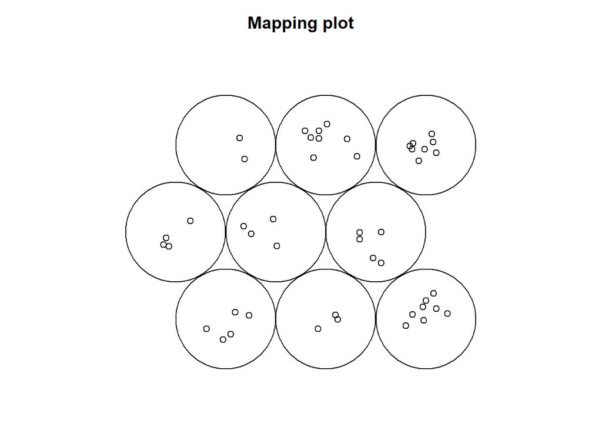

```r
som.swiss = som(scale(swiss), grid = somgrid(xdim = 3, ydim = 3, topo = "hexagonal"))
plot(som.swiss, type = "mapping")
```

Berdasarkan hasil tersebut akan dilihat titik-titik pada map menggunakan sintaks som.swiss$grid$pts dan untuk melihat keanggotaan dari masing-masing observasi digunakan sintaks som.swiss$unit.classif.

```r
som.swiss$grid$pts
```

```
##         x         y
##  [1,] 1.5 0.8660254
##  [2,] 2.5 0.8660254
##  [3,] 3.5 0.8660254
##  [4,] 1.0 1.7320508
##  [5,] 2.0 1.7320508
##  [6,] 3.0 1.7320508
##  [7,] 1.5 2.5980762
##  [8,] 2.5 2.5980762
##  [9,] 3.5 2.5980762
```

```r
som.swiss$unit.classif
```

```
##  [1] 3 9 9 3 3 9 9 9 9 9 9 5 6 3 2 6 3 4 4 2 2 6 5 5 6 3 6 5 1 3 8 8 8 8 8 8 8 8
## [39] 1 1 1 4 3 1 4 7 7
```

Kemudian untuk plot secara keseluruhan, kita gunakan sintaks plot(som.swiss).

```
## Warning in par(opar): argument 1 does not name a graphical parameter
```

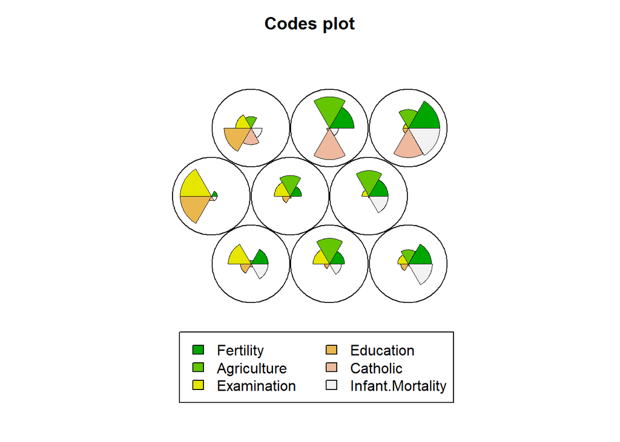

```r
plot(som.swiss)
```

Kemudian kita akan menampilkan data yang dihasilkan oleh analisis SOM

```r
som.swiss$codes[[1]]
```

```
##      Fertility Agriculture Examination   Education   Catholic Infant.Mortality
## V1 -0.25959950 -1.30712906  1.10508066  0.15533665 -0.7037729       0.01579255
## V2 -0.48328882  0.71934168  0.49121548 -0.36757660 -0.9034934      -0.38522066
## V3  0.35796906 -0.32337773 -0.09960034 -0.13808850 -0.7777286       0.55690136
## V4 -1.41399297 -1.63196986  1.96458122  2.19995660 -0.5710944      -0.87717333
## V5 -0.85001680  0.25948188  0.43198257 -0.09654174 -0.7668165      -1.28001580
## V6 -0.05139691  0.69431643 -0.46706983 -0.86513150 -0.7813415       0.18472276
## V7 -1.97606948 -0.58223681  0.36826619  1.75045038  0.2965098      -0.43775276
## V8  0.46627287  1.22705219 -1.15623575 -0.58526603  1.3882294      -0.61489892
## V9  1.18122654  0.06628317 -0.67137712 -0.32688406  1.2409375       1.12436323
```

Data yang semula memiliki 47 objek dari 6 variabel, saat ini menjadi 9 objek dari 6 variabel. Kemudian, kita hitung jarak antar objek menggunakan sintaks dist(som.swiss$codes[[1]]).

```r
dist(som.swiss$codes[[1]])
```

```
##          V1       V2       V3       V4       V5       V6       V7       V8
## V2 2.237764
## V3 1.784595 1.760715
## V4 2.678124 3.938327 4.083972
## V5 2.236618 1.114571 2.336160 3.423304
## V6 2.756211 1.301071 1.416135 4.873171 2.090830
## V7 2.786627 3.141086 3.382831 2.261410 2.689237 3.797663
## V8 4.169563 3.037378 3.129936 5.754486 3.242947 2.539980 4.271004
## V9 3.515879 3.380503 2.364146 5.499276 3.904593 2.686592 4.372348 2.281912
```

Setelah itu kita akan mengelompokkan data menggunakan hierarchical clustering dengan k sebanyak 3.

```r
hclust(dist(som.swiss$codes[[1]]))
```

```
##
## Call:
## hclust(d = dist(som.swiss$codes[[1]]))
##
## Cluster method   : complete
## Distance         : euclidean
## Number of objects: 9
```

Metode yang digunakan dalam pengelompokan adalah metode Complete dan jarak yang digunakan merupakan jarak Euclidean.

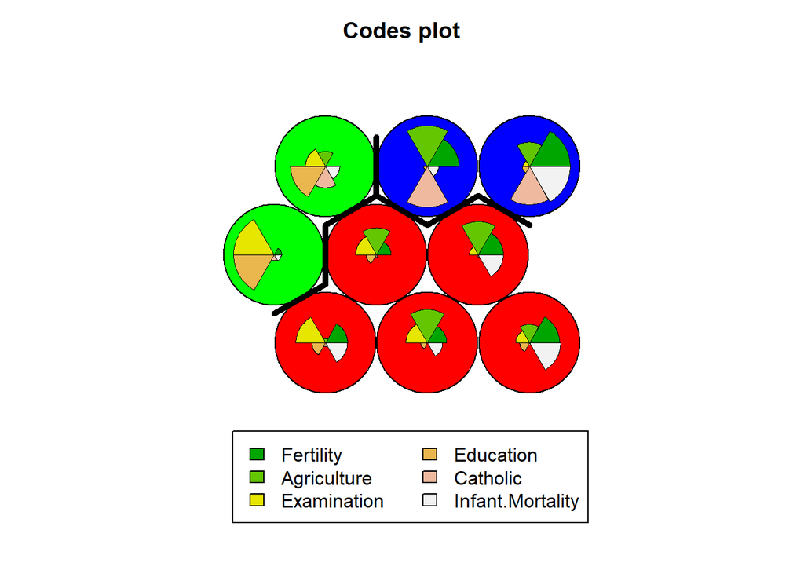

```r
peta = cutree(hclust(dist(som.swiss$codes[[1]])), 3)
plot(som.swiss, type = "codes", bgcol = rainbow(3)[peta])
add.cluster.boundaries(som.swiss, peta)
```

Lalu, bagaimana jika terdapat observasi baru dengan Fertility sebesar 1.03, Agriculture sebesar -0.68, Examination sebesar 0.92, Education sebesar 0.144, Catholic sebesar 1.08, dan Infant Mortality sebesar 1.04, termasuk dalam klasifikasi/lingkaran berapa?

```r
uji = c(1.03, -0.68, 0.92, 0.144, 1.08, 1.04)
ujidf = as.matrix(uji)
dim(ujidf) = c(1, 6)
map(som.swiss, scale(ujidf, center = attr(scale(swiss), "scaled:center"), scale = attr(scale(swiss), "scaled:scale")))
```

```
## $unit.classif
## [1] 5
##
## $distances
## [1] 62.19905
##
## $whatmap
## [1] 1
##
## $user.weights
## [1] 1
```

# Referensi

https://medium.com/@kurniasp/self-organizing-maps-using-kohonen-in-r-a509ac4b25eb